# R Notebook

```r
library(here)
library(dplyr)
library(TwoSampleMR)
library(ieugwasr)
library(ggplot2)
library(data.table)
```

## Analysis plan

1. Most known SBP GWAS hits have been discovered in UKB+ICBP (~460 independent associations). How do they relate to non-European samples? Use CAMERA to estimate maxz and degree of replication
2. Gill et al 2019 (https://www.ahajournals.org/doi/epub/10.1161/CIRCULATIONAHA.118.038814) stratified SNPs by drug target gene. If we split SBP SNPs up into drug regions, do they have consistent effects on non-Europeans? e.g. hypothesise that genetic effects in Europeans at CCB are smaller than in Africans
3. Is inference of effect consistency biased by known SNPs being discovered in European samples? Use Wojcik multi-ancestry SBP SNPs to contrast against UKB+ICBP SNPs
4. Some evidence that dual therapies have differential effects in different populations (https://www.nature.com/articles/s41569-019-0193-2, https://www.nejm.org/doi/10.1056/NEJMoa1901113). Use genetic interactions between SNPs at different drug targets to evaluate this.

## Initial analysis using UK Biobank multi-ancestry sampels

In this analyses we ask whether genetic effects on Europeans a) replicate in non-Europeans and b) have the same effect sizes, and c) whether different drug target genes have different effect sizes in different populations.

SNPs identified by Gill et al (2019).

```r
gill_sbp <- fread(here("data", "gill_sbp.txt"))
gill_sbp %>% str()
```

```
Classes ‘data.table’ and 'data.frame':  31 obs. of  13 variables:
 $ SNP   : chr  "rs4291" "rs11196549" "rs460718" "rs11196597" ...
 $ Chr   : int  17 10 10 10 10 10 10 3 3 3 ...
 $ Pos   : int  61554194 115707298 115721364 115788094 115800294 115805056 115826508 53558012 53605712 53612327 ...
 $ EA    : chr  "a" "a" "a" "a" ...
 $ OA    : chr  "t" "g" "g" "g" ...
 $ EAF   : num  0.6155 0.0425 0.3266 0.133 0.0871 ...
 $ Effect: num  -0.284 0.688 -0.276 0.286 0.328 ...
 $ SE    : num  0.0312 0.0784 0.0324 0.0458 0.0552 0.0344 0.0391 0.0335 0.0958 0.077 ...
 $ P     : num  8.65e-20 1.58e-18 1.36e-17 4.23e-10 2.66e-09 ...
 $ N     : int  745820 738169 738169 737164 738170 738169 738168 736049 737054 737164 ...
 $ Rsq   : num  3.69e-04 1.54e-04 3.34e-04 1.81e-04 1.43e-04 4.97e-04 2.17e-04 4.03e-04 8.02e-05 1.03e-04 ...
 $ Fstat : int  276 114 247 134 106 367 160 297 59 76 ...
 $ gene  : chr  "ACE" "BB" "BB" "BB" ...
 - attr(*, ".internal.selfref")=<externalptr>
```

SBP GWAS datasets for different populations

```r
sbp_eur_id <- "ukb-b-20175"
sbp_afr_id <- "ukb-e-SBP_p2_AFR"
sbp_csa_id <- "ukb-e-SBP_p2_CSA"
sbp_eas_id <- "ukb-e-SBP_p2_EAS"
sbp_mid_id <- "ukb-e-SBP_p2_MID"
out_p2 <- c("ukb-e-SBP_p2_AFR", "ukb-e-SBP_p2_CSA", "ukb-e-SBP_p2_EAS", "ukb-e-SBP_p2_MID")
out_p3 <- c("ukb-e-SBP_p3_AFR", "ukb-e-SBP_p3_CSA", "ukb-e-SBP_p3_EAS", "ukb-e-SBP_p3_MID")

ieugwasr::gwasinfo(c(sbp_eur_id, sbp_afr_id, sbp_csa_id, sbp_eas_id, sbp_mid_id)) %>% str()
```

```
Classes ‘GwasInfo’ and 'data.frame':    5 obs. of  20 variables:
 $ id         : chr  "ukb-b-20175" "ukb-e-SBP_p2_AFR" "ukb-e-SBP_p2_CSA" "ukb-e-SBP_p2_EAS" ...
 $ trait      : chr  "Systolic blood pressure, automated reading" "Systolic blood pressure, combined automated + manual reading" "Systolic blood pressure, combined automated + manual reading" "Systolic blood pressure, combined automated + manual reading" ...
 $ sample_size: int  436419 6614 8842 2705 1590
 $ note       : chr  "4080: Output from GWAS pipeline using Phesant derived variables from UKBiobank" "NA" "NA" "NA" ...
 $ group_name : chr  "public" "public" "public" "public" ...
 $ priority   : int  1 0 0 0 0
 $ mr         : int  1 1 1 1 1
 $ category   : chr  "Continuous" "Continuous" "Continuous" "Continuous" ...
 $ subcategory: logi  NA NA NA NA NA
 $ consortium : chr  "MRC-IEU" "NA" "NA" "NA" ...
 $ unit       : chr  "SD" "NA" "NA" "NA" ...
 $ ontology   : logi  NA NA NA NA NA
 $ sex        : chr  "Males and Females" "Males and Females" "Males and Females" "Males and Females" ...
 $ build      : chr  "HG19/GRCh37" "HG19/GRCh37" "HG19/GRCh37" "HG19/GRCh37" ...
 $ nsnp       : int  9851867 15531889 9812326 8257847 11901176
 $ year       : int  2018 2020 2020 2020 2020
 $ author     : chr  "Ben Elsworth" "Pan-UKB team" "Pan-UKB team" "Pan-UKB team" ...
 $ population : chr  "European" "African American or Afro-Caribbean" "South Asian" "East Asian" ...
 $ ncase      : int  NA 6614 8842 2705 1590
 $ ncontrol   : int  NA 0 0 0 0
```

Get SBP data for EUR

```r
load(here("data", "ukb-e-SBP_p2_EUR.rdata"))
sbp$pval <- 10^(-sbp$LP)
str(sbp)
```

```
tibble [526 × 22] (S3: tbl_df/tbl/data.frame)
 $ seqnames    : Factor w/ 84 levels "1","2","3","4",..: 17 17 17 17 17 17 17 17 17 17 ...
 $ start       : int [1:526] 1371473 2001604 7171356 7455536 7815712 18185510 19922364 30032420 30777924 37335342 ...
 $ end         : int [1:526] 1371473 2001604 7171356 7455536 7815712 18185510 19922364 30032420 30777924 37335342 ...
 $ width       : int [1:526] 1 1 1 1 1 1 1 1 1 1 ...
 $ strand      : Factor w/ 3 levels "+","-","*": 3 3 3 3 3 3 3 3 3 3 ...
 $ paramRangeID: Factor w/ 0 levels: NA NA NA NA NA NA NA NA NA NA ...
 $ REF         : chr [1:526] "C" "T" "C" "C" ...
 $ ALT         : chr [1:526] "G" "A" "T" "T" ...
 $ QUAL        : num [1:526] NA NA NA NA NA NA NA NA NA NA ...
 $ FILTER      : chr [1:526] "PASS" "PASS" "PASS" "PASS" ...
 $ ES          : num [1:526] 0.0144 0.023 0.0165 -0.0169 -0.0244 ...
 $ SE          : num [1:526] 0.00243 0.00386 0.00232 0.00241 0.00412 ...
 $ LP          : num [1:526] 8.5 8.61 11.97 11.63 8.47 ...
 $ AF          : num [1:526] 0.6545 0.0986 0.5457 0.6503 0.0879 ...
 $ SS          : int [1:526] NA NA NA NA NA NA NA NA NA NA ...
 $ EZ          : num [1:526] NA NA NA NA NA NA NA NA NA NA ...
 $ SI          : num [1:526] NA NA NA NA NA NA NA NA NA NA ...
 $ NC          : int [1:526] NA NA NA NA NA NA NA NA NA NA ...
 $ ID          : chr [1:526] NA NA NA NA ...
 $ id          : chr [1:526] "ukb-e-SBP_p2_EUR" "ukb-e-SBP_p2_EUR" "ukb-e-SBP_p2_EUR" "ukb-e-SBP_p2_EUR" ...
 $ rsid        : chr [1:526] "rs8079811" "rs2760748" "rs113086489" "rs4511593" ...
 $ pval        : num [1:526] 3.17e-09 2.48e-09 1.07e-12 2.35e-12 3.36e-09 ...
```

```r
sbp_e <- format_data(sbp, snp_col="rsid", chr_col="seqnames", pos_col="start", effect_allele_col="ALT", other_allele_col="REF", beta_col="ES", se_col="SE", pval_col="pval", eaf_col="AF")
```

```
No phenotype name specified, defaulting to 'exposure'.
```

```r
sbp_o <- extract_outcome_data(gill_sbp$SNP, out_p2)
```

```
Extracting data for 31 SNP(s) from 4 GWAS(s)
Finding proxies for 7 SNPs in outcome ukb-e-SBP_p2_AFR
Extracting data for 7 SNP(s) from 1 GWAS(s)
Finding proxies for 2 SNPs in outcome ukb-e-SBP_p2_CSA
Extracting data for 2 SNP(s) from 1 GWAS(s)
Finding proxies for 10 SNPs in outcome ukb-e-SBP_p2_EAS
Extracting data for 10 SNP(s) from 1 GWAS(s)
Finding proxies for 2 SNPs in outcome ukb-e-SBP_p2_MID
Extracting data for 2 SNP(s) from 1 GWAS(s)
```

```r
sbp_d <- harmonise_data(sbp_e, sbp_o, action=1)
```

```
Harmonising exposure (ukb-e-SBP_p2_EUR) and Systolic blood pressure, combined automated + manual reading || id:ukb-e-SBP_p2_AFR (ukb-e-SBP_p2_AFR)
Harmonising exposure (ukb-e-SBP_p2_EUR) and Systolic blood pressure, combined automated + manual reading || id:ukb-e-SBP_p2_CSA (ukb-e-SBP_p2_CSA)
Harmonising exposure (ukb-e-SBP_p2_EUR) and Systolic blood pressure, combined automated + manual reading || id:ukb-e-SBP_p2_EAS (ukb-e-SBP_p2_EAS)
Harmonising exposure (ukb-e-SBP_p2_EUR) and Systolic blood pressure, combined automated + manual reading || id:ukb-e-SBP_p2_MID (ukb-e-SBP_p2_MID)
```

```r
sbp_d <- inner_join(sbp_d, select(gill_sbp, SNP, target=gene), by="SNP") %>%
  mutate(
    id.exposure=paste0(id.exposure, "_", target),
    exposure=target
  )
res1 <- mr(sbp_d, method_list=c("mr_wald_ratio", "mr_ivw"))
```

```
Analysing 'ukb-e-SBP_p2_EUR_ACE' on 'ukb-e-SBP_p2_AFR'
Analysing 'ukb-e-SBP_p2_EUR_ACE' on 'ukb-e-SBP_p2_CSA'
Analysing 'ukb-e-SBP_p2_EUR_ACE' on 'ukb-e-SBP_p2_EAS'
Analysing 'ukb-e-SBP_p2_EUR_ACE' on 'ukb-e-SBP_p2_MID'
Analysing 'ukb-e-SBP_p2_EUR_BB' on 'ukb-e-SBP_p2_AFR'
Analysing 'ukb-e-SBP_p2_EUR_BB' on 'ukb-e-SBP_p2_CSA'
Analysing 'ukb-e-SBP_p2_EUR_BB' on 'ukb-e-SBP_p2_EAS'
Analysing 'ukb-e-SBP_p2_EUR_BB' on 'ukb-e-SBP_p2_MID'
Analysing 'ukb-e-SBP_p2_EUR_CCB' on 'ukb-e-SBP_p2_AFR'
Analysing 'ukb-e-SBP_p2_EUR_CCB' on 'ukb-e-SBP_p2_CSA'
Analysing 'ukb-e-SBP_p2_EUR_CCB' on 'ukb-e-SBP_p2_EAS'
Analysing 'ukb-e-SBP_p2_EUR_CCB' on 'ukb-e-SBP_p2_MID'
```

```r
load(here("data", "sbp_tophits.rdata"))
sbp_o <- extract_outcome_data(sbp_tophits$rsid, out_p2)
```

```
Extracting data for 461 SNP(s) from 4 GWAS(s)
Finding proxies for 30 SNPs in outcome ukb-e-SBP_p2_AFR
Extracting data for 30 SNP(s) from 1 GWAS(s)
Finding proxies for 11 SNPs in outcome ukb-e-SBP_p2_CSA
Extracting data for 11 SNP(s) from 1 GWAS(s)
Finding proxies for 34 SNPs in outcome ukb-e-SBP_p2_EAS
Extracting data for 34 SNP(s) from 1 GWAS(s)
Finding proxies for 7 SNPs in outcome ukb-e-SBP_p2_MID
Extracting data for 7 SNP(s) from 1 GWAS(s)
```

```r
sbp_th_dat <- harmonise_data(sbp_e, sbp_o, action=1) %>%
  mutate(
    id.exposure="UKB+ICBP discovery",
    exposure=id.exposure
  )
```

```
Harmonising exposure (ukb-e-SBP_p2_EUR) and Systolic blood pressure, combined automated + manual reading || id:ukb-e-SBP_p2_AFR (ukb-e-SBP_p2_AFR)
Harmonising exposure (ukb-e-SBP_p2_EUR) and Systolic blood pressure, combined automated + manual reading || id:ukb-e-SBP_p2_CSA (ukb-e-SBP_p2_CSA)
Harmonising exposure (ukb-e-SBP_p2_EUR) and Systolic blood pressure, combined automated + manual reading || id:ukb-e-SBP_p2_EAS (ukb-e-SBP_p2_EAS)
Harmonising exposure (ukb-e-SBP_p2_EUR) and Systolic blood pressure, combined automated + manual reading || id:ukb-e-SBP_p2_MID (ukb-e-SBP_p2_MID)
```

```r
res2 <- mr(sbp_th_dat, method_list=c("mr_wald_ratio", "mr_ivw"))
```

```
Analysing 'UKB+ICBP discovery' on 'ukb-e-SBP_p2_AFR'
Analysing 'UKB+ICBP discovery' on 'ukb-e-SBP_p2_CSA'
Analysing 'UKB+ICBP discovery' on 'ukb-e-SBP_p2_EAS'
Analysing 'UKB+ICBP discovery' on 'ukb-e-SBP_p2_MID'
```

```r
wojcik <- c("2:26932031", "4:81174592", "7:27243221", "4:81169912", "10:104616663", "4:81184341", "2:127016740", "6:151004770", "8:142389954", "4:81164723", "10:104846178")
sbp_e$chrpos <- paste0(sbp_e$chr.exposure, ":", sbp_e$pos.exposure)
wojcik_rsid <- subset(sbp_e, chrpos %in% wojcik)$SNP
wojcik_rsid
```

```
 [1] "rs4409766"  "rs11191548" "rs2586886"  "rs28515082" "rs1458038"  "rs11099098" "rs13125101" "rs16998073" "rs17080102" "rs2023843"
```

```r
sbp_o <- extract_outcome_data(wojcik_rsid, out_p2)
```

```
Extracting data for 10 SNP(s) from 4 GWAS(s)
```

```r
sbp_th_dat <- harmonise_data(sbp_e, sbp_o, action=1) %>%
  mutate(
    id.exposure="Wojcik non-EUR discovery",
    exposure=id.exposure
  )
```

```
Harmonising exposure (ukb-e-SBP_p2_EUR) and Systolic blood pressure, combined automated + manual reading || id:ukb-e-SBP_p2_AFR (ukb-e-SBP_p2_AFR)
Harmonising exposure (ukb-e-SBP_p2_EUR) and Systolic blood pressure, combined automated + manual reading || id:ukb-e-SBP_p2_CSA (ukb-e-SBP_p2_CSA)
Harmonising exposure (ukb-e-SBP_p2_EUR) and Systolic blood pressure, combined automated + manual reading || id:ukb-e-SBP_p2_EAS (ukb-e-SBP_p2_EAS)
Harmonising exposure (ukb-e-SBP_p2_EUR) and Systolic blood pressure, combined automated + manual reading || id:ukb-e-SBP_p2_MID (ukb-e-SBP_p2_MID)
```

```r
res3 <- mr(sbp_th_dat, method_list=c("mr_wald_ratio", "mr_ivw"))
```

```
Analysing 'Wojcik non-EUR discovery' on 'ukb-e-SBP_p2_AFR'
Analysing 'Wojcik non-EUR discovery' on 'ukb-e-SBP_p2_CSA'
Analysing 'Wojcik non-EUR discovery' on 'ukb-e-SBP_p2_EAS'
Analysing 'Wojcik non-EUR discovery' on 'ukb-e-SBP_p2_MID'
```

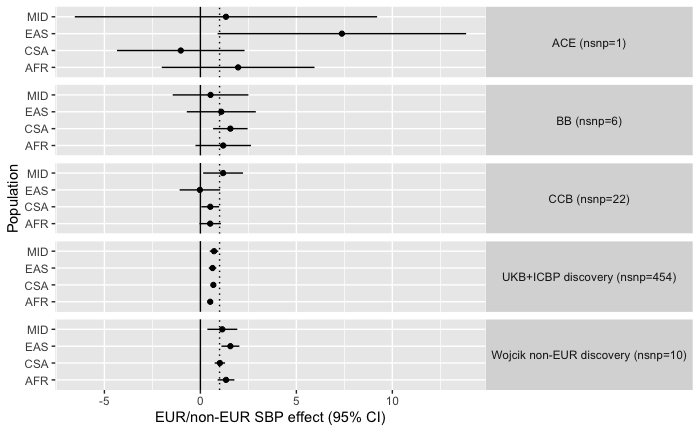

```r
res <- bind_rows(res1, res2, res3)
temp <- group_by(res, exposure) %>% summarise(n=max(nsnp))
res <- inner_join(res, temp)
subset(res, method %in% c("Wald ratio", "Inverse variance weighted")) %>%
  mutate(pop=gsub("ukb-e-SBP_p2_", "", id.outcome), gene=paste0(exposure, " (nsnp=", n,")")) %>%
  ggplot(., aes(x=b, y=pop)) +
  geom_point() +
  geom_errorbarh(aes(xmin=b-1.96*se, xmax=b+1.96*se), height=0) +
  geom_vline(xintercept=1, linetype="dotted") +
  geom_vline(xintercept=0) +
  facet_grid(gene ~ .) +
  labs(x="EUR/non-EUR SBP effect (95% CI)", y="Population") +
  theme(strip.text.y=element_text(angle=0))
```

Re-run with SBP corrected for medication use

```r
load(here("data", "ukb-e-SBP_p3_EUR.rdata"))
sbp$pval <- 10^(-sbp$LP)
str(sbp_p3)
```

```
tibble [526 × 21] (S3: tbl_df/tbl/data.frame)
 $ seqnames    : Factor w/ 84 levels "1","2","3","4",..: 17 17 17 17 17 17 17 17 17 17 ...
 $ start       : int [1:526] 1371473 2001604 7171356 7455536 7815712 18185510 19922364 30032420 30777924 37335342 ...
 $ end         : int [1:526] 1371473 2001604 7171356 7455536 7815712 18185510 19922364 30032420 30777924 37335342 ...
 $ width       : int [1:526] 1 1 1 1 1 1 1 1 1 1 ...
 $ strand      : Factor w/ 3 levels "+","-","*": 3 3 3 3 3 3 3 3 3 3 ...
 $ paramRangeID: Factor w/ 0 levels: NA NA NA NA NA NA NA NA NA NA ...
 $ REF         : chr [1:526] "C" "T" "C" "C" ...
 $ ALT         : chr [1:526] "G" "A" "T" "T" ...
 $ QUAL        : num [1:526] NA NA NA NA NA NA NA NA NA NA ...
 $ FILTER      : chr [1:526] "PASS" "PASS" "PASS" "PASS" ...
 $ ES          : num [1:526] 0.0182 0.0244 0.0207 -0.0202 -0.0292 ...
 $ SE          : num [1:526] 0.00248 0.00394 0.00236 0.00246 0.0042 ...
 $ LP          : num [1:526] 12.76 9.22 17.68 15.63 11.43 ...
 $ AF          : num [1:526] 0.6545 0.0987 0.5457 0.6504 0.0879 ...
 $ SS          : int [1:526] NA NA NA NA NA NA NA NA NA NA ...
 $ EZ          : num [1:526] NA NA NA NA NA NA NA NA NA NA ...
 $ SI          : num [1:526] NA NA NA NA NA NA NA NA NA NA ...
 $ NC          : int [1:526] NA NA NA NA NA NA NA NA NA NA ...
 $ ID          : chr [1:526] NA NA NA NA ...
 $ id          : chr [1:526] "ukb-e-SBP_p3_EUR" "ukb-e-SBP_p3_EUR" "ukb-e-SBP_p3_EUR" "ukb-e-SBP_p3_EUR" ...
 $ rsid        : chr [1:526] "rs8079811" "rs2760748" "rs113086489" "rs4511593" ...
```

```r
sbp_e <- format_data(sbp_p3, snp_col="rsid", chr_col="seqnames", pos_col="start", effect_allele_col="ALT", other_allele_col="REF", beta_col="ES", se_col="SE", pval_col="pval", eaf_col="AF")
```

```
No phenotype name specified, defaulting to 'exposure'.
Inferring p-values
```

```r
sbp_o <- extract_outcome_data(gill_sbp$SNP, out_p3)
```

```
Extracting data for 31 SNP(s) from 4 GWAS(s)
Finding proxies for 7 SNPs in outcome ukb-e-SBP_p3_AFR
Extracting data for 7 SNP(s) from 1 GWAS(s)
Finding proxies for 2 SNPs in outcome ukb-e-SBP_p3_CSA
Extracting data for 2 SNP(s) from 1 GWAS(s)
Finding proxies for 10 SNPs in outcome ukb-e-SBP_p3_EAS
Extracting data for 10 SNP(s) from 1 GWAS(s)
Finding proxies for 2 SNPs in outcome ukb-e-SBP_p3_MID
Extracting data for 2 SNP(s) from 1 GWAS(s)
```

```r
sbp_d <- harmonise_data(sbp_e, sbp_o, action=1)
```

```
Harmonising exposure (ukb-e-SBP_p3_EUR) and Systolic blood pressure, combined automated + manual reading, adjusted by medication || id:ukb-e-SBP_p3_AFR (ukb-e-SBP_p3_AFR)
Harmonising exposure (ukb-e-SBP_p3_EUR) and Systolic blood pressure, combined automated + manual reading, adjusted by medication || id:ukb-e-SBP_p3_CSA (ukb-e-SBP_p3_CSA)
Harmonising exposure (ukb-e-SBP_p3_EUR) and Systolic blood pressure, combined automated + manual reading, adjusted by medication || id:ukb-e-SBP_p3_EAS (ukb-e-SBP_p3_EAS)
Harmonising exposure (ukb-e-SBP_p3_EUR) and Systolic blood pressure, combined automated + manual reading, adjusted by medication || id:ukb-e-SBP_p3_MID (ukb-e-SBP_p3_MID)
```

```r
sbp_d <- inner_join(sbp_d, select(gill_sbp, SNP, target=gene), by="SNP") %>%
  mutate(
    id.exposure=paste0(id.exposure, "_", target),
    exposure=target
  )
res1 <- mr(sbp_d, method_list=c("mr_wald_ratio", "mr_ivw"))
```

```
Analysing 'ukb-e-SBP_p3_EUR_ACE' on 'ukb-e-SBP_p3_AFR'
Analysing 'ukb-e-SBP_p3_EUR_ACE' on 'ukb-e-SBP_p3_CSA'
Analysing 'ukb-e-SBP_p3_EUR_ACE' on 'ukb-e-SBP_p3_EAS'
Analysing 'ukb-e-SBP_p3_EUR_ACE' on 'ukb-e-SBP_p3_MID'
Analysing 'ukb-e-SBP_p3_EUR_BB' on 'ukb-e-SBP_p3_AFR'
Analysing 'ukb-e-SBP_p3_EUR_BB' on 'ukb-e-SBP_p3_CSA'
Analysing 'ukb-e-SBP_p3_EUR_BB' on 'ukb-e-SBP_p3_EAS'
Analysing 'ukb-e-SBP_p3_EUR_BB' on 'ukb-e-SBP_p3_MID'
Analysing 'ukb-e-SBP_p3_EUR_CCB' on 'ukb-e-SBP_p3_AFR'
Analysing 'ukb-e-SBP_p3_EUR_CCB' on 'ukb-e-SBP_p3_CSA'
Analysing 'ukb-e-SBP_p3_EUR_CCB' on 'ukb-e-SBP_p3_EAS'
Analysing 'ukb-e-SBP_p3_EUR_CCB' on 'ukb-e-SBP_p3_MID'
```

```r
load(here("data", "sbp_tophits.rdata"))
sbp_o <- extract_outcome_data(sbp_tophits$rsid, out_p3)
```

```
Extracting data for 461 SNP(s) from 4 GWAS(s)
Finding proxies for 31 SNPs in outcome ukb-e-SBP_p3_AFR
Extracting data for 31 SNP(s) from 1 GWAS(s)
Finding proxies for 11 SNPs in outcome ukb-e-SBP_p3_CSA
Extracting data for 11 SNP(s) from 1 GWAS(s)
Finding proxies for 33 SNPs in outcome ukb-e-SBP_p3_EAS
Extracting data for 33 SNP(s) from 1 GWAS(s)
Finding proxies for 7 SNPs in outcome ukb-e-SBP_p3_MID
Extracting data for 7 SNP(s) from 1 GWAS(s)
```

```r
sbp_th_dat <- harmonise_data(sbp_e, sbp_o, action=1) %>%
  mutate(
    id.exposure="UKB+ICBP discovery",
    exposure=id.exposure
  )
```

```
Harmonising exposure (ukb-e-SBP_p3_EUR) and Systolic blood pressure, combined automated + manual reading, adjusted by medication || id:ukb-e-SBP_p3_AFR (ukb-e-SBP_p3_AFR)
Harmonising exposure (ukb-e-SBP_p3_EUR) and Systolic blood pressure, combined automated + manual reading, adjusted by medication || id:ukb-e-SBP_p3_CSA (ukb-e-SBP_p3_CSA)
Harmonising exposure (ukb-e-SBP_p3_EUR) and Systolic blood pressure, combined automated + manual reading, adjusted by medication || id:ukb-e-SBP_p3_EAS (ukb-e-SBP_p3_EAS)
Harmonising exposure (ukb-e-SBP_p3_EUR) and Systolic blood pressure, combined automated + manual reading, adjusted by medication || id:ukb-e-SBP_p3_MID (ukb-e-SBP_p3_MID)
```

```r
res2 <- mr(sbp_th_dat, method_list=c("mr_wald_ratio", "mr_ivw"))
```

```
Analysing 'UKB+ICBP discovery' on 'ukb-e-SBP_p3_AFR'
Analysing 'UKB+ICBP discovery' on 'ukb-e-SBP_p3_CSA'
Analysing 'UKB+ICBP discovery' on 'ukb-e-SBP_p3_EAS'
Analysing 'UKB+ICBP discovery' on 'ukb-e-SBP_p3_MID'
```

```r
wojcik <- c("2:26932031", "4:81174592", "7:27243221", "4:81169912", "10:104616663", "4:81184341", "2:127016740", "6:151004770", "8:142389954", "4:81164723", "10:104846178")
sbp_e$chrpos <- paste0(sbp_e$chr.exposure, ":", sbp_e$pos.exposure)
wojcik_rsid <- subset(sbp_e, chrpos %in% wojcik)$SNP
wojcik_rsid
```

```
 [1] "rs4409766"  "rs11191548" "rs2586886"  "rs28515082" "rs1458038"  "rs11099098" "rs13125101" "rs16998073" "rs17080102" "rs2023843"
```

```r
sbp_o <- extract_outcome_data(wojcik_rsid, out_p3)
```

```
Extracting data for 10 SNP(s) from 4 GWAS(s)
```

```r
sbp_th_dat <- harmonise_data(sbp_e, sbp_o, action=1) %>%
  mutate(
    id.exposure="Wojcik non-EUR discovery",
    exposure=id.exposure
  )
```

```
Harmonising exposure (ukb-e-SBP_p3_EUR) and Systolic blood pressure, combined automated + manual reading, adjusted by medication || id:ukb-e-SBP_p3_AFR (ukb-e-SBP_p3_AFR)
Harmonising exposure (ukb-e-SBP_p3_EUR) and Systolic blood pressure, combined automated + manual reading, adjusted by medication || id:ukb-e-SBP_p3_CSA (ukb-e-SBP_p3_CSA)
Harmonising exposure (ukb-e-SBP_p3_EUR) and Systolic blood pressure, combined automated + manual reading, adjusted by medication || id:ukb-e-SBP_p3_EAS (ukb-e-SBP_p3_EAS)
Harmonising exposure (ukb-e-SBP_p3_EUR) and Systolic blood pressure, combined automated + manual reading, adjusted by medication || id:ukb-e-SBP_p3_MID (ukb-e-SBP_p3_MID)
```

```r
res3 <- mr(sbp_th_dat, method_list=c("mr_wald_ratio", "mr_ivw"))
```

```
Analysing 'Wojcik non-EUR discovery' on 'ukb-e-SBP_p3_AFR'
Analysing 'Wojcik non-EUR discovery' on 'ukb-e-SBP_p3_CSA'
Analysing 'Wojcik non-EUR discovery' on 'ukb-e-SBP_p3_EAS'
Analysing 'Wojcik non-EUR discovery' on 'ukb-e-SBP_p3_MID'
```

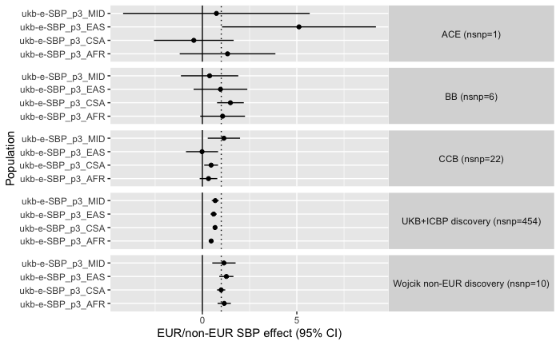

```r
res <- bind_rows(res1, res2, res3)
temp <- group_by(res, exposure) %>% summarise(n=max(nsnp))
res <- inner_join(res, temp)
subset(res, method %in% c("Wald ratio", "Inverse variance weighted")) %>%
  mutate(pop=gsub("ukb-e-SBP_p2_", "", id.outcome), gene=paste0(exposure, " (nsnp=", n,")")) %>%
  ggplot(., aes(x=b, y=pop)) +
  geom_point() +
  geom_errorbarh(aes(xmin=b-1.96*se, xmax=b+1.96*se), height=0) +
  geom_vline(xintercept=1, linetype="dotted") +
  geom_vline(xintercept=0) +
  facet_grid(gene ~ .) +
  labs(x="EUR/non-EUR SBP effect (95% CI)", y="Population") +
  theme(strip.text.y=element_text(angle=0))
```

### Summary

- Genetic effects in CCB appear to be larger in Europeans than Africans, but BB and ACE are more consistent
- Using all European discovery SNPs leads to overestimation of European effect size, but using multi-ancestry discovery rectifies this

## pQTL analysis

```r
load(here("data", "aric_pqtl.rdata"))
str(aric_pqtl)
```

```
Classes ‘data.table’ and 'data.frame':  11785 obs. of  16 variables:
 $ #CHROM   : int  17 17 17 17 17 17 17 17 17 17 ...
 $ POS      : int  62977113 62977169 62977237 62977575 62977770 62977789 62977831 62978029 62978348 62978487 ...
 $ ID       : chr  "rs62076587" "rs73339652" "rs73339653" "rs191151594" ...
 $ REF      : chr  "A" "A" "T" "A" ...
 $ ALT      : chr  "C" "G" "A" "T" ...
 $ A1       : chr  "C" "G" "A" "T" ...
 $ A1_FREQ  : num  0.345 0.0748 0.0748 0.012 0.0401 ...
 $ TEST     : chr  "ADD" "ADD" "ADD" "ADD" ...
 $ OBS_CT   : int  1871 1871 1871 1871 1871 1871 1871 1871 1871 1871 ...
 $ BETA     : num  -0.115 -0.441 -0.441 0.239 -0.138 ...
 $ SE       : num  0.0348 0.0619 0.0619 0.1507 0.0827 ...
 $ T_STAT   : num  -3.3 -7.12 -7.12 1.59 -1.66 ...
 $ P        : num  9.81e-04 1.49e-12 1.49e-12 1.12e-01 9.61e-02 ...
 $ ERRCODE  : chr  "." "." "." "." ...
 $ gene_name: chr  "ACE" "ACE" "ACE" "ACE" ...
 $ pop      : chr  "AFR" "AFR" "AFR" "AFR" ...
 - attr(*, ".internal.selfref")=<externalptr>
```

```r
table(aric_pqtl$pop, aric_pqtl$gene_name)
```

```
       ACE CACNB4
  AFR 3974   3809
  EUR 1737   2265
```

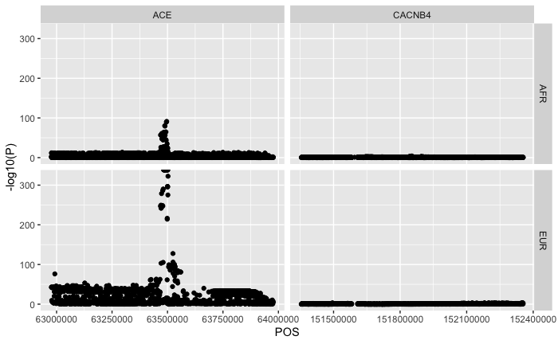

```r
ggplot(aric_pqtl, aes(x=POS, y=-log10(P))) +
  geom_point() +
  facet_grid(pop ~ gene_name, scale="free_x")
```

```r
aric_pqtl %>%
  group_by(pop, gene_name) %>%
  mutate(fdr=p.adjust(P, "fdr")) %>%
  summarise(min_fdr=min(fdr))
```

| pop | gene_name | min_fdr |
| --- | --- | --- |
| AFR | ACE | 2.050962e-88 |
| AFR | CACNB4 | 2.365027e-01 |
| EUR | ACE | 0.000000e+00 |
| EUR | CACNB4 | 1.412697e-01 |

No pQTLs for CCB in ARIC

## eQTL analysis in MESA

```r
load(here("data", "mesa_eqtl.rdata"))
str(mesa_eqtl)
```

```
Classes ‘data.table’ and 'data.frame':  39418 obs. of  16 variables:
 $ snps     : chr  "rs145151443" "rs76279111" "rs16830162" "rs114314477" ...
 $ gene     : chr  "ENSG00000081248" "ENSG00000081248" "ENSG00000081248" "ENSG00000081248" ...
 $ statistic: num  -3.41 -3.36 -3.29 3.05 3.02 ...
 $ pvalue   : num  0.000755 0.00091 0.001172 0.002593 0.002825 ...
 $ FDR      : num  0.0993 0.1124 0.1322 0.2116 0.222 ...
 $ beta     : num  -0.46 -0.415 -0.256 0.286 0.233 ...
 $ chr      : int  1 1 1 1 1 1 1 1 1 1 ...
 $ gene_name: chr  "CACNA1S" "CACNA1S" "CACNA1S" "CACNA1S" ...
 $ start    : int  201008642 201008642 201008642 201008642 201008642 201008642 201008642 201008642 201008642 201008642 ...
 $ end      : int  201081694 201081694 201081694 201081694 201081694 201081694 201081694 201081694 201081694 201081694 ...
 $ gene_type: chr  "protein_coding" "protein_coding" "protein_coding" "protein_coding" ...
 $ pos_snps : int  200055728 201559709 202011500 201147723 201190307 200183160 200179526 200173100 200172655 201247147 ...
 $ ref      : chr  "C" "G" "C" "A" ...
 $ alt      : chr  "T" "A" "T" "G" ...
 $ pop      : chr  "AFA" "AFA" "AFA" "AFA" ...
 $ fdr      : num  0.716 0.716 0.716 0.716 0.716 ...
 - attr(*, ".internal.selfref")=<externalptr>
```

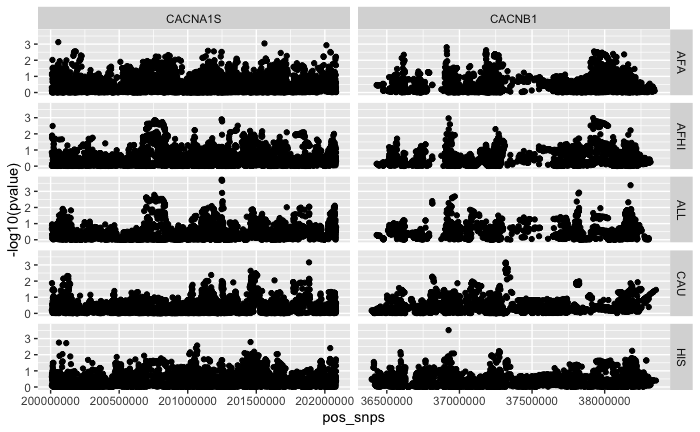

```r
ggplot(mesa_eqtl, aes(x=pos_snps, y=-log10(pvalue))) +
  geom_point() +
  facet_grid(pop ~ gene_name, scale="free_x")
```

```r
mesa_eqtl %>%
  group_by(pop, gene_name) %>%
  mutate(fdr=p.adjust(pvalue, "fdr")) %>%
  summarise(min_fdr=min(fdr))
```

| pop | gene_name | min_fdr |
| --- | --- | --- |
| AFA | CACNA1S | 0.7753382 |
| AFA | CACNB1 | 0.3386188 |
| AFHI | CACNA1S | 0.4224076 |
| AFHI | CACNB1 | 0.1917293 |
| ALL | CACNA1S | 0.2765759 |
| ALL | CACNB1 | 0.4436547 |
| CAU | CACNA1S | 0.5336530 |
| CAU | CACNB1 | 0.5507925 |
| HIS | CACNA1S | 0.9997982 |
| HIS | CACNB1 | 0.9629775 |

No eQTLs for CCB in MESA.

## eQTL in eQTLGen

```r
load(here("data", "eqtlgen.rdata"))
str(eqtlgen)
```

```
tibble [26 × 14] (S3: tbl_df/tbl/data.frame)
 $ position       : int [1:26] 135837906 56987765 56883438 115707296 115846302 115799477 50474624 53516203 53735766 2782070 ...
 $ beta           : num [1:26] -0.0728 -0.1078 -0.0759 -0.1189 0.3334 ...
 $ chr            : chr [1:26] "2" "16" "16" "10" ...
 $ p              : num [1:26] 1.20e-09 6.11e-17 1.75e-10 1.00e-08 5.62e-11 ...
 $ n              : num [1:26] 8269 13925 14260 25827 5926 ...
 $ se             : num [1:26] 0.012 0.0129 0.0119 0.0208 0.0509 ...
 $ id             : chr [1:26] "eqtl-a-ENSG00000070915" "eqtl-a-ENSG00000070915" "eqtl-a-ENSG00000070915" "eqtl-a-ENSG00000043591" ...
 $ rsid           : chr [1:26] "rs7570971" "rs56228609" "rs8044753" "rs717368" ...
 $ ea             : chr [1:26] "A" "T" "A" "G" ...
 $ nea            : chr [1:26] "C" "C" "G" "A" ...
 $ eaf            : num [1:26] 0.4412 0.3056 0.522 0.0902 0.0138 ...
 $ ensembl_gene_id: chr [1:26] "ENSG00000070915" "ENSG00000070915" "ENSG00000070915" "ENSG00000043591" ...
 $ hgnc_symbol    : chr [1:26] "SLC12A3" "SLC12A3" "SLC12A3" "ADRB1" ...
 $ pop            : chr [1:26] "EUR" "EUR" "EUR" "EUR" ...
```

```r
sbp_o <- extract_outcome_data(eqtlgen$rsid, out_p3)
```

```
Extracting data for 26 SNP(s) from 4 GWAS(s)
Finding proxies for 4 SNPs in outcome ukb-e-SBP_p3_AFR
Extracting data for 4 SNP(s) from 1 GWAS(s)
Finding proxies for 3 SNPs in outcome ukb-e-SBP_p3_CSA
Extracting data for 3 SNP(s) from 1 GWAS(s)
Finding proxies for 4 SNPs in outcome ukb-e-SBP_p3_EAS
Extracting data for 4 SNP(s) from 1 GWAS(s)
Finding proxies for 1 SNPs in outcome ukb-e-SBP_p3_MID
Extracting data for 1 SNP(s) from 1 GWAS(s)
```

```r
sbp_d <- harmonise_data(sbp_e, sbp_o, action=1)
```

```
Harmonising exposure (ukb-e-SBP_p3_EUR) and Systolic blood pressure, combined automated + manual reading, adjusted by medication || id:ukb-e-SBP_p3_AFR (ukb-e-SBP_p3_AFR)
Harmonising exposure (ukb-e-SBP_p3_EUR) and Systolic blood pressure, combined automated + manual reading, adjusted by medication || id:ukb-e-SBP_p3_CSA (ukb-e-SBP_p3_CSA)
Harmonising exposure (ukb-e-SBP_p3_EUR) and Systolic blood pressure, combined automated + manual reading, adjusted by medication || id:ukb-e-SBP_p3_EAS (ukb-e-SBP_p3_EAS)
Harmonising exposure (ukb-e-SBP_p3_EUR) and Systolic blood pressure, combined automated + manual reading, adjusted by medication || id:ukb-e-SBP_p3_MID (ukb-e-SBP_p3_MID)
```

```r
sbp_d <- inner_join(sbp_d, select(eqtlgen, SNP=rsid, target=hgnc_symbol), by="SNP") %>%
  mutate(
    id.exposure=paste0(id.exposure, "_", target),
    exposure=target
  )
res1 <- mr(sbp_d, method_list=c("mr_wald_ratio", "mr_ivw"))
```

```
Analysing 'ukb-e-SBP_p3_EUR_ACE' on 'ukb-e-SBP_p3_AFR'
Analysing 'ukb-e-SBP_p3_EUR_ACE' on 'ukb-e-SBP_p3_CSA'
Analysing 'ukb-e-SBP_p3_EUR_ACE' on 'ukb-e-SBP_p3_EAS'
Analysing 'ukb-e-SBP_p3_EUR_ACE' on 'ukb-e-SBP_p3_MID'
Analysing 'ukb-e-SBP_p3_EUR_ADRB1' on 'ukb-e-SBP_p3_AFR'
Analysing 'ukb-e-SBP_p3_EUR_ADRB1' on 'ukb-e-SBP_p3_CSA'
Analysing 'ukb-e-SBP_p3_EUR_ADRB1' on 'ukb-e-SBP_p3_EAS'
Analysing 'ukb-e-SBP_p3_EUR_ADRB1' on 'ukb-e-SBP_p3_MID'
Analysing 'ukb-e-SBP_p3_EUR_CACNA1C' on 'ukb-e-SBP_p3_AFR'
Analysing 'ukb-e-SBP_p3_EUR_CACNA1C' on 'ukb-e-SBP_p3_CSA'
Analysing 'ukb-e-SBP_p3_EUR_CACNA1C' on 'ukb-e-SBP_p3_EAS'
Analysing 'ukb-e-SBP_p3_EUR_CACNA1C' on 'ukb-e-SBP_p3_MID'
Analysing 'ukb-e-SBP_p3_EUR_CACNA1D' on 'ukb-e-SBP_p3_AFR'
Analysing 'ukb-e-SBP_p3_EUR_CACNA1D' on 'ukb-e-SBP_p3_CSA'
Analysing 'ukb-e-SBP_p3_EUR_CACNA1D' on 'ukb-e-SBP_p3_EAS'
Analysing 'ukb-e-SBP_p3_EUR_CACNA1D' on 'ukb-e-SBP_p3_MID'
Analysing 'ukb-e-SBP_p3_EUR_CACNA2D2' on 'ukb-e-SBP_p3_AFR'
Analysing 'ukb-e-SBP_p3_EUR_CACNA2D2' on 'ukb-e-SBP_p3_CSA'
Analysing 'ukb-e-SBP_p3_EUR_CACNA2D2' on 'ukb-e-SBP_p3_MID'
Analysing 'ukb-e-SBP_p3_EUR_CACNB1' on 'ukb-e-SBP_p3_AFR'
Analysing 'ukb-e-SBP_p3_EUR_CACNB1' on 'ukb-e-SBP_p3_CSA'
Analysing 'ukb-e-SBP_p3_EUR_CACNB1' on 'ukb-e-SBP_p3_EAS'
Analysing 'ukb-e-SBP_p3_EUR_CACNB1' on 'ukb-e-SBP_p3_MID'
Analysing 'ukb-e-SBP_p3_EUR_CACNB2' on 'ukb-e-SBP_p3_AFR'
Analysing 'ukb-e-SBP_p3_EUR_CACNB2' on 'ukb-e-SBP_p3_CSA'
Analysing 'ukb-e-SBP_p3_EUR_CACNB2' on 'ukb-e-SBP_p3_EAS'
Analysing 'ukb-e-SBP_p3_EUR_CACNB2' on 'ukb-e-SBP_p3_MID'
Analysing 'ukb-e-SBP_p3_EUR_CACNB3' on 'ukb-e-SBP_p3_AFR'
Analysing 'ukb-e-SBP_p3_EUR_CACNB3' on 'ukb-e-SBP_p3_CSA'
Analysing 'ukb-e-SBP_p3_EUR_CACNB3' on 'ukb-e-SBP_p3_EAS'
Analysing 'ukb-e-SBP_p3_EUR_CACNB3' on 'ukb-e-SBP_p3_MID'
Analysing 'ukb-e-SBP_p3_EUR_CACNB4' on 'ukb-e-SBP_p3_AFR'
Analysing 'ukb-e-SBP_p3_EUR_CACNB4' on 'ukb-e-SBP_p3_CSA'
Analysing 'ukb-e-SBP_p3_EUR_CACNB4' on 'ukb-e-SBP_p3_EAS'
Analysing 'ukb-e-SBP_p3_EUR_CACNB4' on 'ukb-e-SBP_p3_MID'
Analysing 'ukb-e-SBP_p3_EUR_SLC12A3' on 'ukb-e-SBP_p3_AFR'
Analysing 'ukb-e-SBP_p3_EUR_SLC12A3' on 'ukb-e-SBP_p3_CSA'
Analysing 'ukb-e-SBP_p3_EUR_SLC12A3' on 'ukb-e-SBP_p3_EAS'
Analysing 'ukb-e-SBP_p3_EUR_SLC12A3' on 'ukb-e-SBP_p3_MID'
```

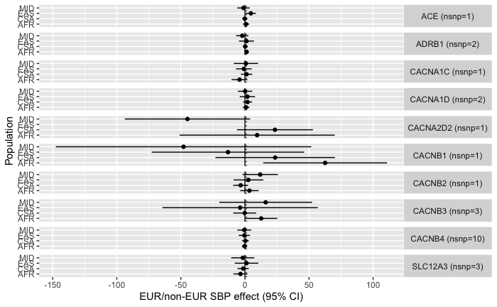

```r
temp <- group_by(res1, exposure) %>% summarise(n=max(nsnp))
res1 <- inner_join(res1, temp)
subset(res1, method %in% c("Wald ratio", "Inverse variance weighted")) %>%
  mutate(pop=gsub("ukb-e-SBP_p3_", "", id.outcome), gene=paste0(exposure, " (nsnp=", n,")")) %>%
  ggplot(., aes(x=b, y=pop)) +
  geom_point() +
  geom_errorbarh(aes(xmin=b-1.96*se, xmax=b+1.96*se), height=0) +
  geom_vline(xintercept=1, linetype="dotted") +
  geom_vline(xintercept=0) +
  facet_grid(gene ~ .) +
  labs(x="EUR/non-EUR SBP effect (95% CI)", y="Population") +
  theme(strip.text.y=element_text(angle=0))
```

Re-run using only SNPs that have fdr < 0.05 in Europeans

```r
keep <- subset(sbp_e, SNP %in% sbp_d$SNP) %>%
  mutate(fdr=p.adjust(pval.exposure, "fdr")) %>%
  filter(fdr < 0.05)
res1 <- mr(sbp_d %>% filter(SNP %in% keep$SNP), method_list=c("mr_wald_ratio", "mr_ivw"))
```

```
Analysing 'ukb-e-SBP_p3_EUR_ACE' on 'ukb-e-SBP_p3_AFR'
Analysing 'ukb-e-SBP_p3_EUR_ACE' on 'ukb-e-SBP_p3_CSA'
Analysing 'ukb-e-SBP_p3_EUR_ACE' on 'ukb-e-SBP_p3_EAS'
Analysing 'ukb-e-SBP_p3_EUR_ACE' on 'ukb-e-SBP_p3_MID'
Analysing 'ukb-e-SBP_p3_EUR_ADRB1' on 'ukb-e-SBP_p3_AFR'
Analysing 'ukb-e-SBP_p3_EUR_ADRB1' on 'ukb-e-SBP_p3_CSA'
Analysing 'ukb-e-SBP_p3_EUR_ADRB1' on 'ukb-e-SBP_p3_EAS'
Analysing 'ukb-e-SBP_p3_EUR_ADRB1' on 'ukb-e-SBP_p3_MID'
Analysing 'ukb-e-SBP_p3_EUR_CACNA1C' on 'ukb-e-SBP_p3_AFR'
Analysing 'ukb-e-SBP_p3_EUR_CACNA1C' on 'ukb-e-SBP_p3_CSA'
Analysing 'ukb-e-SBP_p3_EUR_CACNA1C' on 'ukb-e-SBP_p3_EAS'
Analysing 'ukb-e-SBP_p3_EUR_CACNA1C' on 'ukb-e-SBP_p3_MID'
Analysing 'ukb-e-SBP_p3_EUR_CACNA1D' on 'ukb-e-SBP_p3_AFR'
Analysing 'ukb-e-SBP_p3_EUR_CACNA1D' on 'ukb-e-SBP_p3_CSA'
Analysing 'ukb-e-SBP_p3_EUR_CACNA1D' on 'ukb-e-SBP_p3_EAS'
Analysing 'ukb-e-SBP_p3_EUR_CACNA1D' on 'ukb-e-SBP_p3_MID'
Analysing 'ukb-e-SBP_p3_EUR_CACNB4' on 'ukb-e-SBP_p3_AFR'
Analysing 'ukb-e-SBP_p3_EUR_CACNB4' on 'ukb-e-SBP_p3_CSA'
Analysing 'ukb-e-SBP_p3_EUR_CACNB4' on 'ukb-e-SBP_p3_EAS'
Analysing 'ukb-e-SBP_p3_EUR_CACNB4' on 'ukb-e-SBP_p3_MID'
```

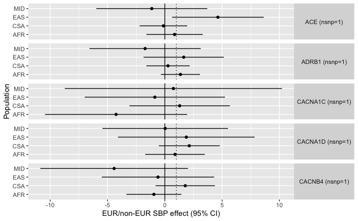

```r
temp <- group_by(res1, exposure) %>% summarise(n=max(nsnp))
res1 <- inner_join(res1, temp)
subset(res1, method %in% c("Wald ratio", "Inverse variance weighted")) %>%
  mutate(pop=gsub("ukb-e-SBP_p3_", "", id.outcome), gene=paste0(exposure, " (nsnp=", n,")")) %>%
  ggplot(., aes(x=b, y=pop)) +
  geom_point() +
  geom_errorbarh(aes(xmin=b-1.96*se, xmax=b+1.96*se), height=0) +
  geom_vline(xintercept=1, linetype="dotted") +
  geom_vline(xintercept=0) +
  facet_grid(gene ~ .) +
  labs(x="EUR/non-EUR SBP effect (95% CI)", y="Population") +
  theme(strip.text.y=element_text(angle=0))
```

Difficult to make much inference here, need larger sample size in non-Europeans

## Next steps

1. GWAS of SBP in each ancestry - making sure to analyse scale and attempt to harmonise measurements
2. Perform multiple ancestry finemapping for SBP loci
3. Stratify instruments by drug target to determine if relative SNP effects across populations differ
4. Analysis of SBP drug loci associate with eQTLs / pQTLs
5. Factorial MR / Analysis of interactions: do genetic effects across drug targets interact